# Manejo de Datos, Estadísticas Descriptivas y Visualización en R

D. S. Fernández del Viso

2024-12-18

### Cargar Datos en R

En R, puedes cargar datos desde archivos externos como .csv, .txt, .xls o .xlsx. Para cargar un archivo .csv, puedes usar la función `read.csv()` o `read.csv2()`.

Vamos a cargar los datos de tres archivos que utilizaremos en este documento:

1. `diabetes.csv`: Datos de una población de mujeres de la etnia Pima en Arizona.

```r
# Cargar datos desde archivo .csv
diabetes <- read.csv("diabetes.csv")
head(diabetes)
```

```
##   Pregnancies Glucose BloodPressure SkinThickness Insulin  BMI
## 1           6     148            72            35       0 33.6
## 2           1      85            66            29       0 26.6
## 3           8     183            64             0       0 23.3
## 4           1      89            66            23      94 28.1
## 5           0     137            40            35     168 43.1
## 6           5     116            74             0       0 25.6
##   DiabetesPedigreeFunction Age Outcome
## 1                    0.627  50       1
## 2                    0.351  31       0
## 3                    0.672  32       1
## 4                    0.167  21       0
## 5                    2.288  33       1
## 6                    0.201  30       0
```

2. `calcio-ratas.csv`: Datos de un estudio sobre el efecto de estrógenos sobre el calcio plasmático en ratas.

```r
# Cargar datos desde archivo .csv
calcio_ratas <- read.csv("calcio-ratas.csv")
head(calcio_ratas)
```

```
##   caplasma hormona   sexo
## 1     16.3      no hembra
## 2     20.4      no hembra
## 3     12.4      no hembra
## 4     15.8      no hembra
## 5      9.5      no hembra
## 6     15.3      no  macho
```

3. `melocactus.xlsx`: Datos de un estudio sobre una población de *Melocactus intortus* en Guánica, Puerto Rico.

```r
# Cargar datos desde archivo .xlsx
library(readxl)
melocactus <- read_excel("melocactus.xlsx", sheet = "2019")
head(melocactus)
```

```
## # A tibble: 6 × 7
##   grupo planta_id azimuto distancia altura_planta long_inflo estado
##   <chr>     <dbl>   <dbl>     <dbl>         <dbl>      <dbl> <chr>
## 1 N             1      35      6.22            51         17 E
## 2 N             2      35      6.22            24         10 X
## 3 N             3      35      6.22             3          0 E
## 4 N             4      25      6.67            20         20 X
## 5 N             5      25      4.53            36          9 S
## 6 N             6      24      4.53             8          0 E
```

### Manejo del archivo `diabetes.csv`

Utilizaremos el paquete `tidyverse` para limpiar, seleccionar, filtrar y transformar los datos del archivo `diabetes.csv`. Permite el uso de funciones como `select()`, `filter()`, `mutate()`, `rename()`, entre otras y la concatenación de operaciones con el operador `%>%`.

#### Cambio de nombres de columnas

```r
library(tidyverse)
# Cambiar nombres de columnas
diabetes1 <- diabetes %>%
  rename(
    edad = Age,
    embarazos = Pregnancies,
    glucosa = Glucose,
    presion = BloodPressure,
    pliegues = SkinThickness,
    insulina = Insulin,
    imc = BMI,
    gen_diabetes = DiabetesPedigreeFunction,
    edad_diagnostico = Age,
    diabetes = Outcome
  )

head(diabetes1)
```

```
##   embarazos glucosa presion pliegues insulina  imc gen_diabetes
## 1         6     148      72       35        0 33.6        0.627
## 2         1      85      66       29        0 26.6        0.351
## 3         8     183      64        0        0 23.3        0.672
## 4         1      89      66       23       94 28.1        0.167
## 5         0     137      40       35      168 43.1        2.288
## 6         5     116      74        0        0 25.6        0.201
##   edad_diagnostico diabetes
## 1               50        1
## 2               31        0
## 3               32        1
## 4               21        0
## 5               33        1
## 6               30        0
```

#### Seleccionar columnas

Vamos a seleccionar las columnas que tengan información sobre glucosa, insulina, pedigree de diabetes y diagnóstico.

```r
# Seleccionar columnas
diabetes2 <- diabetes1 %>%
  select(glucosa, insulina, gen_diabetes, diabetes)

head(diabetes2)
```

```
##   glucosa insulina gen_diabetes diabetes
## 1     148        0        0.627        1
## 2      85        0        0.351        0
## 3     183        0        0.672        1
## 4      89       94        0.167        0
## 5     137      168        2.288        1
## 6     116        0        0.201        0
```

##### Ejercicio: selecciona las variables físicas (edad, presión, imc) y el diagnóstico de diabetes.

#### Filtrar datos

Vamos a crear dos nuevos conjuntos de datos: uno de las diagnosticadas con diabetes y otro de las no diagnosticadas.

```r
# Filtrar datos de acuerdo al diagnóstico de diabetes
diabetes_diagnosticadas <- diabetes1 %>%
  filter(diabetes == 1)

diabetes_no_diagnosticadas <- diabetes1 %>%
  filter(diabetes == 0)

# guardar en archivos .csv sin numero de fila
write.csv(diabetes_diagnosticadas, "diabetes_diagnosticadas.csv", row.names = FALSE)
write.csv(diabetes_no_diagnosticadas, "diabetes_no_diagnosticadas.csv", row.names = FALSE)
```

##### Ejercicio: filtra los datos de las mujeres con más de 30 años y guarda en un archivo .csv sin número de fila.

#### Crear nueva variable

Vamos a crear la variable índice glucosa/insulina.

```r
# Crear nueva variable sin tomar en cuenta valores de insulina y glucosa iguales a 0
diabetes3 <- diabetes1 %>%
  filter(insulina != 0 & glucosa != 0) %>%
  mutate(indice_gi = glucosa / insulina)

head(diabetes3)
```

```
##   embarazos glucosa presion pliegues insulina  imc gen_diabetes
## 1         1      89      66       23       94 28.1        0.167
## 2         0     137      40       35      168 43.1        2.288
## 3         3      78      50       32       88 31.0        0.248
## 4         2     197      70       45      543 30.5        0.158
## 5         1     189      60       23      846 30.1        0.398
## 6         5     166      72       19      175 25.8        0.587
##   edad_diagnostico diabetes indice_gi
## 1               21        0 0.9468085
## 2               33        1 0.8154762
## 3               26        1 0.8863636
## 4               53        1 0.3627993
## 5               59        1 0.2234043
## 6               51        1 0.9485714
```

#### Ejercicio: crea una nueva variable con el índice imc/presión. Filtra los datos para que no tengan valores de presión o imc iguales a 0.

### Estadísticas descriptivas de `diabetes.csv`

#### Estadísticas por grupos

Vamos a calcular las estadísticas descriptivas - media y desviación estándar - de las variables glucosa e insulina agrupadas por el diagnóstico de diabetes. En cada caso vamos a filtrar los datos que sean ceros.

```r
# Estadísticas descriptivas de glucosa e insulina por diagnóstico de diabetes
estadisticas_diabetes <- diabetes1 %>%
  filter(glucosa != 0 & insulina != 0) %>%
  group_by(diabetes) %>%
  summarise(
    media_glucosa = mean(glucosa),
    desviacion_glucosa = sd(glucosa),
    media_insulina = mean(insulina),
    desviacion_insulina = round(sd(insulina),1)
  )
estadisticas_diabetes
```

```
## # A tibble: 2 × 5
##   diabetes media_glucosa desviacion_glucosa media_insulina desviacion_insulina
##      <int>         <dbl>              <dbl>          <dbl>               <dbl>
## 1        0          111.               24.6           131.                102.
## 2        1          145.               29.8           207.                133.
```

Vamos a crear una tabla `gt` con los resultados

```r
# tabla con gt cambiando los nombres
library(gt)

estadisticas_diabetes %>%
  gt() %>%
  tab_header(
    title = "Tabla 1.  Estadísticas de Glucosa e Insulina por Diagnóstico de Diabetes. Datos de mujeres de la etnia Pima en Arizona"
  ) %>%
  cols_label(
    diabetes = "Diagnóstico",
    media_glucosa = "Media Glucosa",
    desviacion_glucosa = "D. E. Glucosa",
    media_insulina = "Media Insulina",
    desviacion_insulina = "D. E. Insulina"
  )
```

Tabla 1. Estadísticas de Glucosa e Insulina por Diagnóstico de Diabetes. Datos de mujeres de la etnia Pima en Arizona

| Diagnóstico | Media Glucosa | D. E. Glucosa | Media Insulina | D. E. Insulina |
| --- | --- | --- | --- | --- |
| 0 | 111.4563 | 24.59840 | 130.6958 | 102.5 |
| 1 | 145.1923 | 29.83939 | 206.8462 | 132.7 |

##### Ejercicio: calcula las estadísticas descriptivas de las variables físicas (edad, presión, imc) por diagnóstico de diabetes. Filtra los datos para que no tengan valores de presión o imc iguales a 0.

##### Ejercicio: redondea los valores a una cifra decimal y vuelve a crear las tablas con `gt`.

### Estadísticas descriptivas en `calcio-ratas.csv`

Vamos a crear una tabla agrupando por hormona y sexo y calculando la media y desviación estándar del calcio plasmático.

```r
# Estadísticas descriptivas de calcio plasmático por hormona y sexo
estadisticas_calcio <- calcio_ratas %>%
  group_by(hormona, sexo) %>%
  summarise(
    media_calcio = mean(caplasma),
    desviacion_calcio = sd(caplasma)
) %>%
  ungroup()
estadisticas_calcio
```

```
## # A tibble: 4 × 4
##   hormona sexo   media_calcio desviacion_calcio
##   <chr>   <chr>         <dbl>             <dbl>
## 1 no      hembra         14.9              4.14
## 2 no      macho          12.1              4.25
## 3 si      hembra         32.5              4.67
## 4 si      macho          27.8              4.29
```

Crear una tabla `gt` con los resultados

```r
# tabla con gt cambiando los nombres
estadisticas_calcio %>%
  gt() %>%
  tab_header(
    title = "Tabla 2.  Estadísticas de Calcio Plasmático por Hormona y Sexo. Datos de un estudio sobre el efecto de estrógenos sobre el calcio plasmático en ratas"
  ) %>%
  cols_label(
    sexo = "Sexo",
    hormona = "Hormona",
    media_calcio = "Media Calcio",
    desviacion_calcio = "D. E. Calcio"
  )
```

Tabla 2. Estadísticas de Calcio Plasmático por Hormona y Sexo. Datos de un estudio sobre el efecto de estrógenos sobre el calcio plasmático en ratas

| Hormona | Sexo | Media Calcio | D. E. Calcio |
| --- | --- | --- | --- |
| no | hembra | 14.88 | 4.136061 |
| no | macho | 12.12 | 4.247588 |
| si | hembra | 32.52 | 4.670867 |
| si | macho | 27.78 | 4.287423 |

##### Ejercicio: calcula el error estándar de la media y vuelve a crear la tabla con `gt`. La fórmula para el error estándar de la media es `sd(caplasma) / sqrt(n())`.

### Manejo de datos en `melocactus.xlsx`

#### Creación de nuevas variables

Vamos a crear las variables coordX y coordY a partir de la variables azimuto y distancia, utilizando las fórmulas:

- coordX = distancia * sin(azimuto)
- coordY = distancia * cos(azimuto)

El azimuto está en grados, por lo que debemos convertirlo a radianes mediante la fórmula:

- radianes = grados * pi / 180

También vamos a sumar 100 a las coordenadas para que no sean negativas.

```r
# Crear nuevas variables coordX y coordY
melocactus1 <- melocactus %>%
  mutate(
    radianes = azimuto * pi / 180,
    coordX = distancia * sin(radianes) + 100,
    coordY = distancia * cos(radianes) + 100
  )

head(melocactus1)
```

```
## # A tibble: 6 × 10
##   grupo planta_id azimuto distancia altura_planta long_inflo estado radianes
##   <chr>     <dbl>   <dbl>     <dbl>         <dbl>      <dbl> <chr>     <dbl>
## 1 N             1      35      6.22            51         17 E         0.611
## 2 N             2      35      6.22            24         10 X         0.611
## 3 N             3      35      6.22             3          0 E         0.611
## 4 N             4      25      6.67            20         20 X         0.436
## 5 N             5      25      4.53            36          9 S         0.436
## 6 N             6      24      4.53             8          0 E         0.419
## # ℹ 2 more variables: coordX <dbl>, coordY <dbl>
```

#### Filtrar datos

Vamos a filtrar los datos para que solo incluyan las plantas que tienen inflorescencia con longitud mayor que 0.

```r
# Filtrar datos para inflorescencias con longitud mayor que 0
melocactus2 <- melocactus1 %>%
  filter(long_inflo > 0)

head(melocactus2)
```

```
## # A tibble: 6 × 10
##   grupo planta_id azimuto distancia altura_planta long_inflo estado radianes
##   <chr>     <dbl>   <dbl>     <dbl>         <dbl>      <dbl> <chr>     <dbl>
## 1 N             1      35      6.22            51         17 E         0.611
## 2 N             2      35      6.22            24         10 X         0.611
## 3 N             4      25      6.67            20         20 X         0.436
## 4 N             5      25      4.53            36          9 S         0.436
## 5 N             9     343      6.54            47         11 E         5.99
## 6 N            12     344      1.34             6          1 X         6.00
## # ℹ 2 more variables: coordX <dbl>, coordY <dbl>
```

#### Ejercicio: filtrar los datos para tener solo las plantas sanas (S).

### Estadísticas descriptivas en `melocactus.xlsx`

Obtener las proporciones de plantas sanas (S), enfermas (E) y muertas (X) en la población.

```r
# Estadísticas descriptivas de estado de las plantas
estadisticas_melocactus <- melocactus1 %>%
  group_by(estado) %>%
  summarise(
    prop = n() / nrow(melocactus1)
  ) %>%
  ungroup()
estadisticas_melocactus
```

```
## # A tibble: 3 × 2
##   estado  prop
##   <chr>  <dbl>
## 1 E      0.256
## 2 S      0.52
## 3 X      0.224
```

```r
# cambiar nombres de estado
estadisticas_melocactus <- estadisticas_melocactus %>%
  mutate(
    estado = case_when(
      estado == "E" ~ "Enfermas",
      estado == "S" ~ "Sanas",
      estado == "X" ~ "Muertas"
    )
  )
```

Crear una tabla `gt` con los resultados

```r
# tabla con gt cambiando los nombres
estadisticas_melocactus %>%
  gt() %>%
  tab_header(
    title = "Tabla 3.  Proporción de Plantas Sanas, Enfermas y Muertas. Datos de un estudio sobre una población de *Melocactus intortus* en Guánica, Puerto Rico"
  ) %>%
  cols_label(
    estado = "Estado",
    prop = "Proporción"
  )
```

Tabla 3. Proporción de Plantas Sanas, Enfermas y Muertas. Datos de un estudio sobre una población de *Melocactus intortus* en Guánica, Puerto Rico

| Estado | Proporción |
| --- | --- |
| Enfermas | 0.256 |
| Sanas | 0.520 |
| Muertas | 0.224 |

##### Ejercicio: usar `table()` para contar las plantas por estado.

### Visualización de Datos de `diabetes.csv`

#### Histogramas

Vamos a crear un histograma para las variables glucosa e insulina. Usaremos el paquete `ggplot2` para crear gráficos. El archivo que usaremos es `diabetes3` que está filtrado para valores de cero.

#### Histograma de glucosa

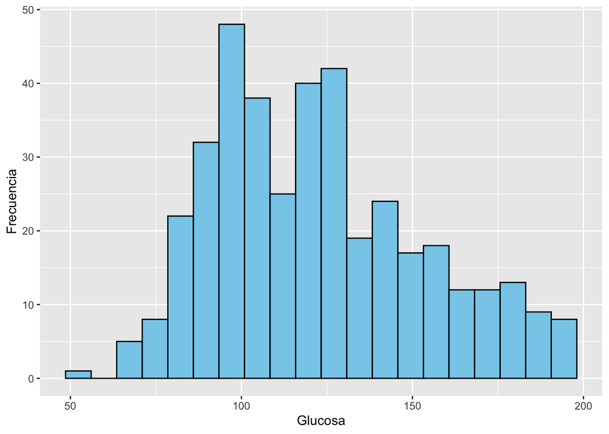

```r
# Histograma de glucosa
library(ggplot2)

hist_gluco <- ggplot(diabetes3, aes(x = glucosa)) +
  geom_histogram(fill = "skyblue", color = "black", bins = 20) +
  labs(
    x = "Glucosa",
    y = "Frecuencia"
  )
hist_gluco
```

**Figura 1.** Histograma de glucosa. Datos de mujeres de la etnia Pima en Arizona.

#### Histograma de insulina

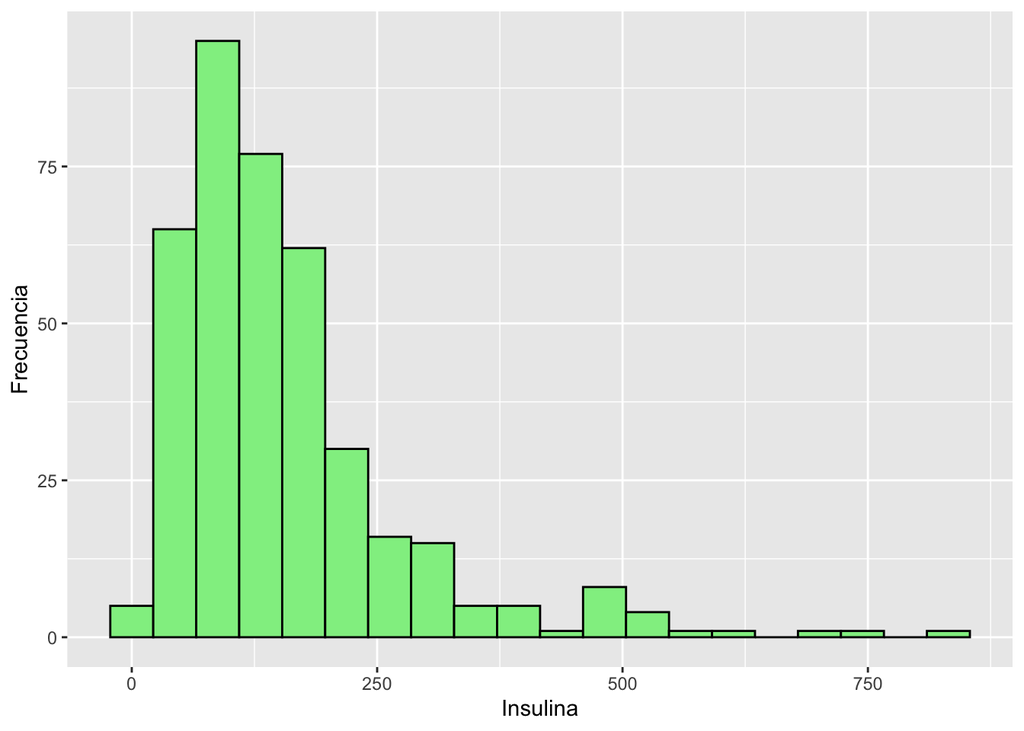

```r
# Histograma de insulina
hist_insulina <- ggplot(diabetes3, aes(x = insulina)) +
  geom_histogram(fill = "lightgreen", color = "black", bins = 20) +
  labs(
    x = "Insulina",
    y = "Frecuencia"
  )
hist_insulina
```

**Figura 2.** Histograma de insulina. Datos de mujeres de la etnia Pima en Arizona.

##### Ejercicio: crea un histograma de la variable índice glucosa/insulina.

### Gráfico de dispersión

Vamos a crear un gráfico de dispersión para las variables glucosa e insulina.

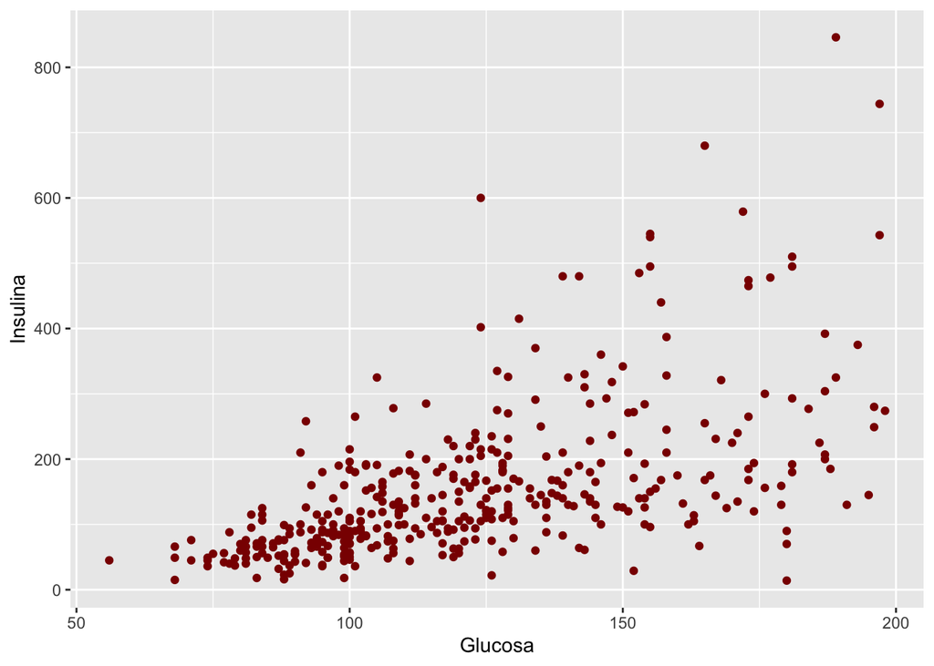

```r
# Gráfico de dispersión de glucosa e insulina
scatter_gluco_insulina <- ggplot(diabetes3, aes(x = glucosa, y = insulina)) +
  geom_point(color = "darkred") +
  labs(
    x = "Glucosa",
    y = "Insulina"
  )
scatter_gluco_insulina
```

**Figura 3.** Gráfico de Dispersión de Glucosa e Insulina. Datos de mujeres de la etnia Pima en Arizona.

##### Ejercicio: crea un gráfico de dispersión para las variables índice glucosa/insulina.

### Visualización de Datos de `calcio-ratas.csv`

#### Gráfica de barras separadas

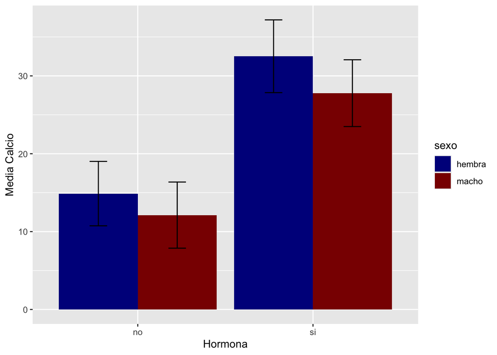

```r
# Gráfica de barras separadas de calcio plasmático por hormona y sexo usando los datos de calcio-ratas.csv
bar_calcio <- ggplot(estadisticas_calcio, aes(x = hormona, y = media_calcio, fill = sexo)) +
  geom_bar(stat = "identity", position = "dodge") +
  geom_errorbar(aes(ymin = media_calcio - desviacion_calcio, ymax = media_calcio + desviacion_calcio), width = 0.2, position = position_dodge(0.9)) +
  labs(
    x = "Hormona",
    y = "Media Calcio"
  ) +
  scale_fill_manual(values = c("darkblue", "darkred"))

bar_calcio
```

**Figura 4.** Gráfica de Barras de Calcio Plasmático por Hormona y Sexo. Datos de un estudio sobre el efecto de estrógenos sobre el calcio plasmático en ratas.

#### Gráfica de cajas

Vamos a crear una gráfica de cajas para el calcio plasmático por hormona y sexo.

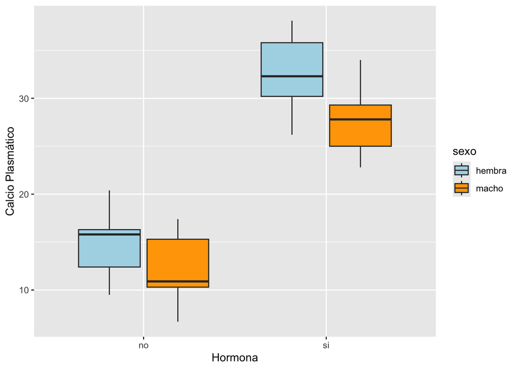

```r
# Gráfica de cajas de calcio plasmático por hormona y sexo
box_calcio <- ggplot(calcio_ratas, aes(x = hormona, y = caplasma, fill = sexo)) +
  geom_boxplot() +
  labs(
    x = "Hormona",
    y = "Calcio Plasmático"
  ) +
  scale_fill_manual(values = c("lightblue", "orange"))

box_calcio
```

**Figura 5.** Gráfica de Cajas de Calcio Plasmático por Hormona y Sexo. Datos de un estudio sobre el efecto de estrógenos sobre el calcio plasmático en ratas.

### Visualización de Datos de `melocactus.xlsx`

#### Mapa de ubicación de plantas

Vamos a crear un mapa de ubicación de las plantas de *Melocactus intortus* en Guánica, Puerto Rico.

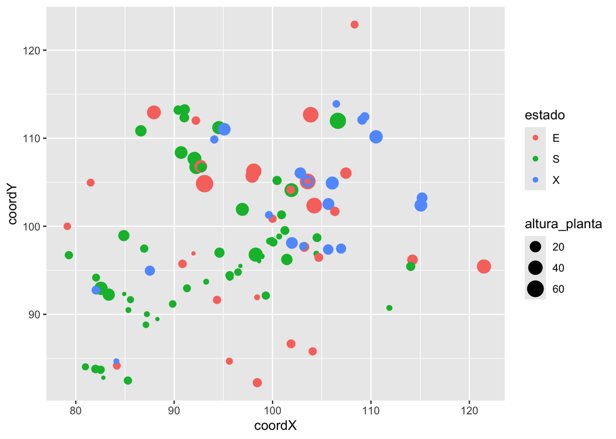

```r
melo = ggplot(melocactus1, aes(coordX, coordY, color = estado, size = altura_planta)) +
  geom_point()
melo
```

**Figura 6.** Mapa de Ubicación de Plantas de *Melocactus intortus* en Guánica, Puerto Rico. Incluye información sobre el estado de las plantas y la altura de las plantas.

#### Gráfico de dispersión

Vamos a crear un gráfico de dispersión para la altura de las plantas y la longitud de la inflorescencia.

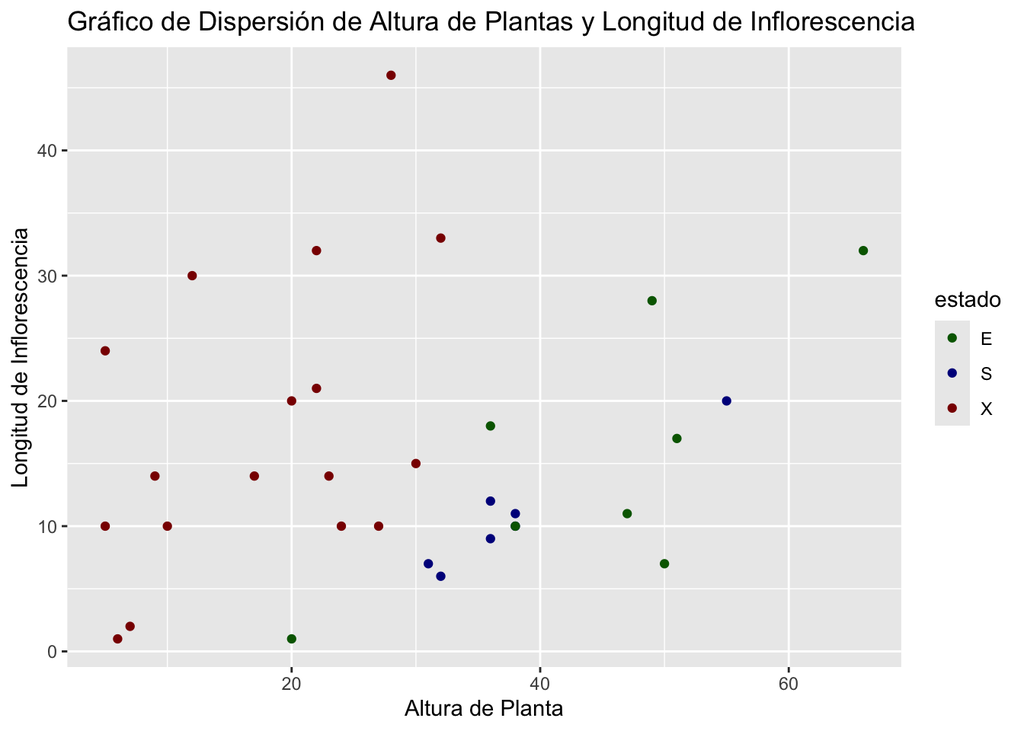

```r
scatter_altura_inflo <- ggplot(melocactus2, aes(x = altura_planta, y = long_inflo, color = estado)) +
  geom_point() +
  labs(
    title = "Gráfico de Dispersión de Altura de Plantas y Longitud de Inflorescencia",
    x = "Altura de Planta",
    y = "Longitud de Inflorescencia"
  ) +
  scale_color_manual(values = c("darkgreen", "darkblue", "darkred"))

scatter_altura_inflo
```

### Gráfica de barras de altura promedio por estado

Vamos a crear una gráfica de barras para la altura promedio de las plantas por estado y su error estándar.

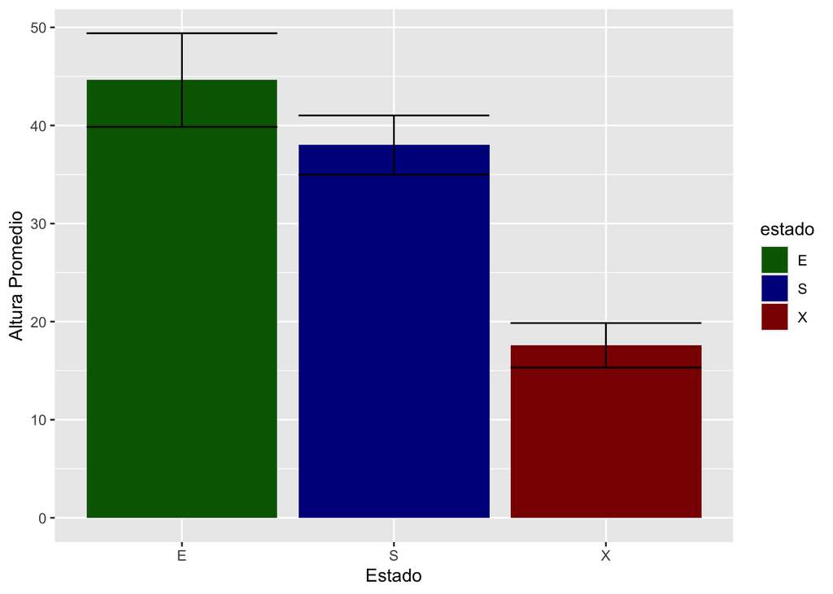

```r
# Gráfica de barras de altura promedio por estado
bar_altura <- ggplot(melocactus2, aes(x = estado, y = altura_planta, fill = estado)) +
  geom_bar(stat = "summary", fun = "mean", position = "dodge") +
  geom_errorbar(stat = "summary", fun.data = "mean_se", position = position_dodge(0.9)) +
  labs(
    x = "Estado",
    y = "Altura Promedio"
  ) +
  scale_fill_manual(values = c("darkgreen", "darkblue", "darkred"))

bar_altura
```

**Figura 9.** Gráfica de Barras de Altura Promedio por Estado. Datos de un estudio sobre una población de *Melocactus intortus* en Guánica, Puerto Rico.

##### Ejercicio: crea una gráfica de barras de la longitud promedio de la inflorescencia por estado y su error estándar.